## Measurecamp 2019 - CPH

**Creating datapipelines with R**

*By Danny Mawani Holmgaard*

## Agenda

1. About my journey
2. Stuff I am still figuring out
3. Learn to grab different types of data
4. Connect **Github** and **Cloud Storage**
5. Use **R** in the **GCP**
6. Extract Transform and Load data into BigQuery

# My journey

## What I do

- Worked with Digital Analytics for 5 years
- Lead Analyst @ IMPACT EXTEND
- Responsible for all data pipelines
- Moving from digital analytics to data engineering
- Primarily use R and GCP

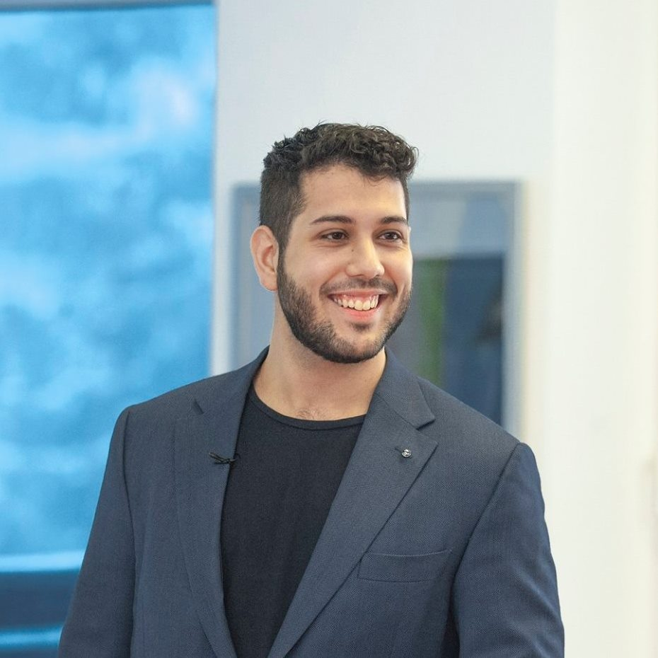

## Our team

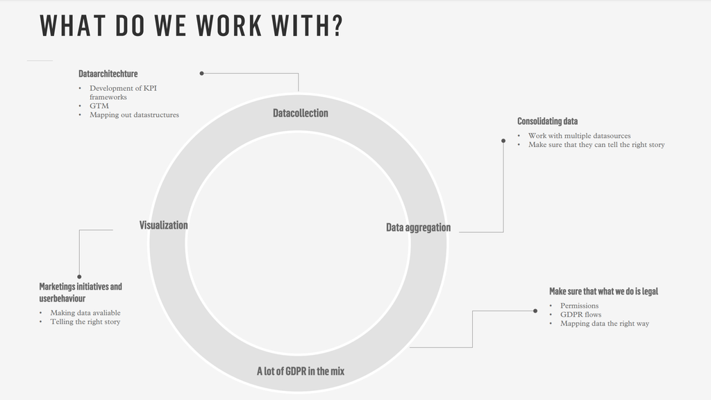

## Stuff I am currently trying to get better at using

- Using Python and SQL instead of using R for everything
- Utilizing Docker
- Set up plumber API’s to make my life easier
- Deploying shinyapps to GCP with authentication

[figure not shown]

# What i am trying to say is that there is a lot to grasp and that it takes time to optimize your workflow

# But now, lets get to the place where we can get to do some cool stuff!

# Grabbing different types of data

## SQL Servers

```r
#load libraries
#library(tidyverse)
#library(dbi)
#library(odbc)

#set up connection object
con <- DBI::dbConnect(odbc::odbc(),
                      Driver    = "SQL Server",
                      Server    = "yourserver.database.windows.net",
                      Database  = "databasename",
                      UID       = "userid",
                      PWD       = "password",
                      Port      = 1234)

#extract data
dataset <- as_tibble(
  tbl(con, "dataset")%>%
  head(100) #Get the first 100 rows
  )
```

## FTP Servers

```r
#library(RCurl)
syntax <- "ftp://"
ftpHost <- "ftp.yourserver.com.com"
ftpUser <- "username"
ftpPass <- "password"
folder <- "/folder/" #delete folder if in root
ftpURL <- paste(syntax,ftpHost,folder,sep = "")

#Download files function

download <- function(file){
  fileDownload <- file
  downloadFtpUrl <- paste(ftpURL,fileDownload, sep = "")
  downloadFtpUrlCredentials <- paste(ftpUser,":",ftpPass, sep = "")
  bin <- getBinaryURL(downloadFtpUrl,userpwd=downloadFtpUrlCredentials)
  con <- file(fileDownload, open = "wb")
  writeBin(bin, con)
  close(con)}

#Download files

download("yourfile.csv")
```

## postgress database

```r
#library('RPostgreSQL')

#create connection object
con <- dbConnect(drv ="RPostgreSQL",
                 user="",
                 password="",
                 host="",
                 port=1234,
                 dbname="")

#extract data
dataset <- as_tibble(
  tbl(con, "dataset")%>%
  head(100) #Get the first 100 rows
  )
```

## Facebook and Instagram

- It is **REALLY** difficult to download Facebook and instagram data
- Therefore you should seek a third party vendor should you need to get datasources that doesnt have easy to access API’s
- Remember, maintaining API work can require a lof of work and could potentially break whereas a vendor are living of maintaining these tools and have the right types of access

[figure not shown]

# Connect Github and Cloud storage to your work

## Github

- Github is the closest thing you get to a “dropbox” for your code.
- It allows version control and makes sure that your code is always updated
- From github, you can push you code into other systems and work on the same projects

[figure not shown]

## Cloud Storage

- Cloud storage lets you upload and pull files in a secure environment
- It has great API’s and can sync directly with bigQuery
- Thanks to Mark Edmonson, we can also source R code directly from there

[figure not shown]

## Setting up the configuration

1. Set up Github and put you code there
2. Create a bucket in Cloud Storage
3. Create a trigger with cloudbuild where you link to the repo
4. Add cloudbuild.yalm to the folder

```javascript
steps:
  - name: gcr.io/cloud-builders/gsutil
    args: ["-m", "rsync", "-r", "-c", "-d", ".", "gs://yourfolderincloudstorage/ifneededthencreateasubfolder"]
```

## Sourcing from Cloud Storage

```r
#install.package("googleCloudStorageR") if you have not installed it yet

#load the library
library(googleCloudStorageR)

#Authenticate
gcs_auth()

googleCloudStorageR::gcs_source('yoursubfolderifyouhaveone/yourscript.R', bucket = 'yourcreatedbucket')
```

# Use R studio in the Google Cloud Platform

## 1. Set up billing

## 2. Thank Mark that he build a script that does everything for you

```r
# You need to authenticate with your GCP account before being able to do it
gce_vm("yourmachinename", project ="gar-creds-185213", zone = "europe-west1-b",
       predefined_type = "g1-small",
       template = "rstudio",
       username = "username",
       password = "password")
```

## The easy way to run scripts automatically from GCS

[figure not shown]

```r
#set machine to be launched
library(googleComputeEngineR)
library(googleCloudStorageR)
library(googleAuthR)

gar_auth("/home/username/.httr-oauth")

GCE_AUTH_FILE="/home/username/auth.json"
GCE_DEFAULT_PROJECT_ID="projectname"
GCE_DEFAULT_ZONE="europe-west1-b"
gcs_global_bucket("bucketname")
BQ_AUTH_FILE="/home/username/bq.oauth"

vm <- gce_vm("yourvirtualmachine")

vm <- gce_ssh_setup(vm,
                    username = "username",
                    key.pub = "/home/username/.ssh/id_rsa.pub",
                    key.private = "/home/username/.ssh/id_rsa")

runme <- "Rscript -e \"googleAuthR::gar_gce_auth();googleCloudStorageR::gcs_source('cloudstoragefolder/script.r', bucket = 'bucket')\""
docker_cmd(vm,
           cmd = "exec",
           args = c("rstudio", runme),
           wait = TRUE,
           capture_text = FALSE)
```

## Automating the script to run at a specific time

*Remember - your if you turn of the machine, the cronjob settings will stop working*

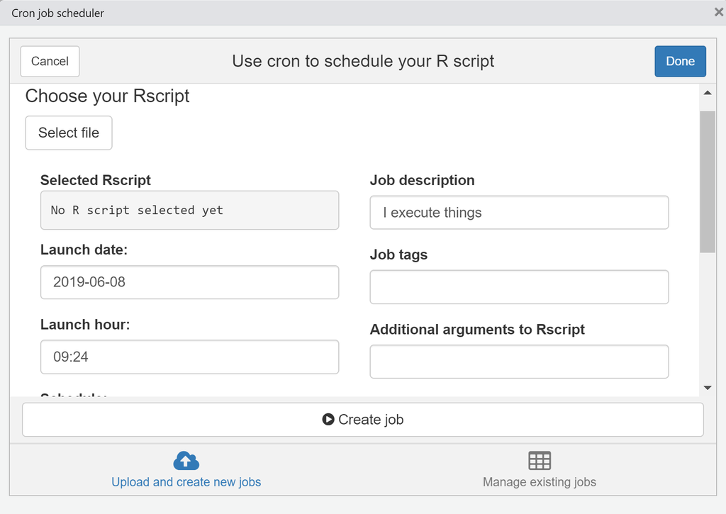

## Sending data to bigQuery

```r
#library(bigQueryR)

# First Create the dataset

# bqr_create_table(projectId = "your project id",
#                  datasetId = "dataset", "your table", your dataframe,
#                  timePartitioning = FALSE, expirationMs = 0L)

bqr_upload_data(projectId = "your project id",
                datasetId = "dataset", "your table", yourdataframe,
                overwrite = FALSE, #True to overwrite your table
                wait = TRUE, autodetect = FALSE,
                maxBadRecords = 1000)
```

## Final thoughts

1. This is not the most stable way to do things, but the easiest
2. There is so many ways you can work with making your data flow
3. Start small and build your way up from there

## Questions?

- @dannymawani (Twitter / Linkedin)
- www.mawani.dk
- dmo@impact.dk